# How bad was July 2026 in Bangalore?

2026-08-05

## Question

How bad was this July in bangalore in terms of rainfall and heat ?

## Analysis frame

- July 2026 is complete in the local archive, so the clean comparison is full July 2026 vs full historical Julys.
- “Heat” is measured by the monthly mean of daily maximum temperature.
- “Rainfall” is measured by total July precipitation.
- I also check how many July days crossed 30°C, 31°C, 32°C, 33°C, and 35°C because average heat can hide a lack of true spikes.
- Data source is the local ERA5 archive only.

## Data prep

```r
temp_hourly <- blrTemp %>%
  transmute(
    DT = as_datetime(DT),
    date = as_date(DT),
    year = year(DT),
    month = month(DT),
    temp_c = as.numeric(Temp)
  ) %>%
  filter(!is.na(temp_c))

rain_hourly <- blrRain %>%
  transmute(
    DT = as_datetime(DT),
    date = as_date(DT),
    year = year(DT),
    month = month(DT),
    rain_mm = as.numeric(Rain)
  ) %>%
  filter(!is.na(rain_mm))

daily_weather <- temp_hourly %>%
  summarise(
    tmin = min(temp_c, na.rm = TRUE),
    tmax = max(temp_c, na.rm = TRUE),
    tmean = mean(temp_c, na.rm = TRUE),
    .by = c(date, year, month)
  ) %>%
  left_join(
    rain_hourly %>%
      summarise(rain_mm = sum(rain_mm, na.rm = TRUE), .by = c(date, year, month)),
    by = c("date", "year", "month")
  ) %>%
  filter(is.finite(tmin), is.finite(tmax), !is.na(rain_mm))

july_stats <- daily_weather %>%
  filter(month == 7) %>%
  summarise(
    mean_tmax = mean(tmax),
    mean_tmin = mean(tmin),
    mean_tmean = mean(tmean),
    max_tmax = max(tmax),
    rain_total = sum(rain_mm),
    rainy_days = sum(rain_mm > 0.1),
    days_30 = sum(tmax >= 30),
    days_31 = sum(tmax >= 31),
    days_32 = sum(tmax >= 32),
    days_33 = sum(tmax >= 33),
    days_35 = sum(tmax >= 35),
    .by = year
  ) %>%
  mutate(
    rank_heat = min_rank(desc(mean_tmax)),
    rank_rain = min_rank(rain_total),
    rank_dry = min_rank(rain_total),
    heat_percentile = percent_rank(mean_tmax),
    rain_percentile = percent_rank(rain_total)
  )

current_july <- july_stats %>% filter(year == analysis_year)
current_july
```

```
##   year mean_tmax mean_tmin mean_tmean max_tmax rain_total rainy_days days_30
## 1 2026  28.23484  21.28387   24.46028    30.68      59.89         26       2
##   days_31 days_32 days_33 days_35 rank_heat rank_rain rank_dry heat_percentile
## 1       0       0       0       0         4         5        5       0.9333333
##   rain_percentile
## 1      0.08888889
```

## Quick facts

```r
july_stats %>%
  summarise(
    year = first(year),
    n_years = n(),
    current_mean_tmax = round(current_july$mean_tmax, 2),
    current_rain_total = round(current_july$rain_total, 1),
    heat_rank = paste0(current_july$rank_heat, " / ", n()),
    rain_rank = paste0(current_july$rank_rain, " / ", n()),
    heat_percentile = round(current_july$heat_percentile, 3),
    rain_percentile = round(current_july$rain_percentile, 3),
    max_tmax = round(current_july$max_tmax, 2),
    days_30 = current_july$days_30,
    days_31 = current_july$days_31,
    days_32 = current_july$days_32,
    days_33 = current_july$days_33,
    days_35 = current_july$days_35,
    rainy_days = current_july$rainy_days
  )
```

```
##   year n_years current_mean_tmax current_rain_total heat_rank rain_rank
## 1 1981      46             28.23               59.9    4 / 46    5 / 46
##   heat_percentile rain_percentile max_tmax days_30 days_31 days_32 days_33
## 1           0.933           0.089    30.68       2       0       0       0
##   days_35 rainy_days
## 1       0         26
```

## Heat and rainfall through time

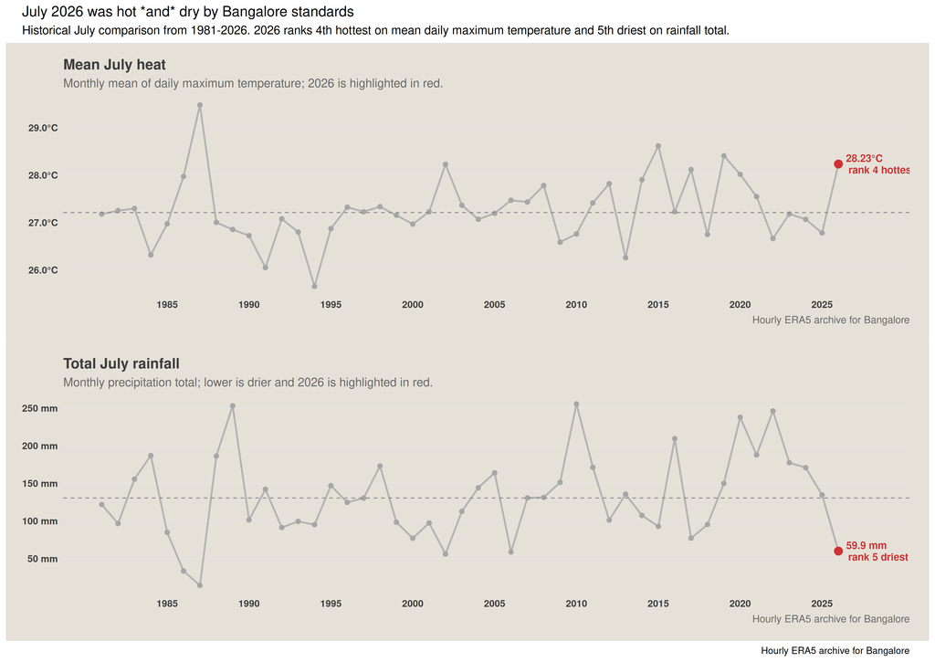

```r
heat_median <- median(july_stats$mean_tmax)
rain_median <- median(july_stats$rain_total)

heat_panel <- ggplot(july_stats, aes(year, mean_tmax)) +
  geom_line(color = "grey70", linewidth = 0.8) +
  geom_point(color = "grey65", size = 1.7) +
  geom_hline(yintercept = heat_median, linetype = "dashed", color = "#888888", linewidth = 0.4) +
  geom_point(data = current_july, color = "#CD3333", size = 3.2) +
  geom_text(
    data = current_july,
    aes(label = paste0(round(mean_tmax, 2), "°C\nrank ", rank_heat, " hottest / ", n_years)),
    hjust = -0.05,
    vjust = 0.5,
    nudge_x = 0.35,
    size = 3.3,
    fontface = "bold",
    color = "#CD3333",
    lineheight = 0.95
  ) +
  scale_x_continuous(breaks = seq(1985, 2025, 5), limits = c(1981, 2028)) +
  scale_y_continuous(labels = label_number(accuracy = 0.1, suffix = "°C")) +
  labs(
    title = "Mean July heat",
    subtitle = "Monthly mean of daily maximum temperature; 2026 is highlighted in red.",
    caption = "Hourly ERA5 archive for Bangalore"
  ) +
  analysis_theme()

rain_panel <- ggplot(july_stats, aes(year, rain_total)) +
  geom_line(color = "grey70", linewidth = 0.8) +
  geom_point(color = "grey65", size = 1.7) +
  geom_hline(yintercept = rain_median, linetype = "dashed", color = "#888888", linewidth = 0.4) +
  geom_point(data = current_july, color = "#CD3333", size = 3.2) +
  geom_text(
    data = current_july,
    aes(label = paste0(round(rain_total, 1), " mm\nrank ", rank_dry, " driest / ", n_years)),
    hjust = -0.05,
    vjust = 0.5,
    nudge_x = 0.35,
    size = 3.3,
    fontface = "bold",
    color = "#CD3333",
    lineheight = 0.95
  ) +
  scale_x_continuous(breaks = seq(1985, 2025, 5), limits = c(1981, 2028)) +
  scale_y_continuous(labels = label_number(suffix = " mm")) +
  labs(
    title = "Total July rainfall",
    subtitle = "Monthly precipitation total; lower is drier and 2026 is highlighted in red.",
    caption = "Hourly ERA5 archive for Bangalore"
  ) +
  analysis_theme()

combined <- heat_panel / rain_panel +
  plot_annotation(
    title = "July 2026 was hot *and* dry by Bangalore standards",
    subtitle = paste0(
      "Historical July comparison from 1981-2026. 2026 ranks ",
      current_july$rank_heat, "th hottest on mean daily maximum temperature and ",
      current_july$rank_rain, "th driest on rainfall total."
    ),
    caption = "Hourly ERA5 archive for Bangalore"
  )

combined
```

```r
chart_path <- file.path(chart_dir, "july_2026_heat_rain.png")
ggsave(chart_path, combined, width = 12, height = 8.5, dpi = 180, bg = "#e5e1d8")
```

## Checks

```r
list(
  analysis_date = analysis_date,
  july_2026_heat_rank = current_july$rank_heat,
  july_2026_rain_rank = current_july$rank_rain,
  july_2026_mean_tmax = current_july$mean_tmax,
  july_2026_rain_total = current_july$rain_total,
  july_2026_days_30 = current_july$days_30,
  july_2026_days_31 = current_july$days_31,
  july_2026_days_32 = current_july$days_32,
  july_2026_days_33 = current_july$days_33,
  july_2026_days_35 = current_july$days_35,
  july_heat_rain_correlation = cor(july_stats$mean_tmax, july_stats$rain_total, use = "complete.obs"),
  july_heat_rain_spearman = cor(july_stats$mean_tmax, july_stats$rain_total, use = "complete.obs", method = "spearman")
)
```

```
## $analysis_date
## [1] "2026-08-05"
##
## $july_2026_heat_rank
## [1] 4
##
## $july_2026_rain_rank
## [1] 5
##
## $july_2026_mean_tmax
## [1] 28.23484
##
## $july_2026_rain_total
## [1] 59.89
##
## $july_2026_days_30
## [1] 2
##
## $july_2026_days_31
## [1] 0
##
## $july_2026_days_32
## [1] 0
##
## $july_2026_days_33
## [1] 0
##
## $july_2026_days_35
## [1] 0
##
## $july_heat_rain_correlation
## [1] -0.3707238
##
## $july_heat_rain_spearman
## [1] -0.3079248
```

## Verdict

Insightful: no

This July was genuinely rough: it was the **4th hottest** July in the archive on mean daily maximum temperature and the **5th driest** on rainfall. But the heat was more persistent than extreme — the hottest day only reached 30.68°C, and there were no 31°C+ or 33°C+ days — so the month reads as a warm, dry monsoon-month rather than a standout heatwave.

That makes it a good factual summary, but not strong enough to publish as a site post. The result is descriptive rather than surprising, and the chart mostly confirms the ranking story in one glance.

Charts:

- `docs/assets/analysis/july_2026_heat_rain.png`

Blog post:

- not published
- if this ever becomes publishable, create `docs/blog/july-2026-heat-rain.html`
- include `This post is AI-written.` at the top of the article body
- end with an `Original question` section containing Work in /home/karthik/apps/bangalore-weather. HERMES DRAFT MODE. Treat the following as the exact weather question trigger_prompt. Follow the Hermes draft workflow in analysis_questions/README.md and AGENTS.md: create and run the analysis notebook, write the Verdict, create analysis charts if needed, and decide insightfulness strictly. Do not create or modify docs/blog, docs/index.html, docs/blog/feed.xml, analysis_questions/analyses.yml, do not commit, and do not push. Reply with the gist of the analysis, the insightfulness verdict, files created, and if publishable ask for explicit approval using /weather_publish . Question: How bad was this July in bangalore in terms of rainfall and heat ?
- add the post to the top of `docs/blog/index.html` and `docs/blog/feed.xml`
- add `blog_url: "blog/july-2026-heat-rain.html"` to the top of `analysis_questions/analyses.yml`